# Homework 3 Predictive analytics

Salma Elshahawy

2021-03-06

[Github repo](https://github.com/salma71/MSDS_spring2021/tree/master/data_624) | [portfolio](https://salma71.github.io/) | [Blog](https://salmaeng71.medium.com/)

## Problem 6.2

The `plastics` data set consists of the monthly sales (in thousands) of product A for a plastics manufacturer for five years.

**a. Plot the time series of sales of product A. Can you identify seasonal fluctuations and/or a trend-cycle?**

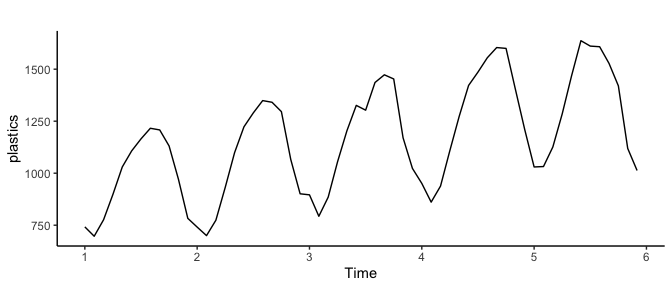

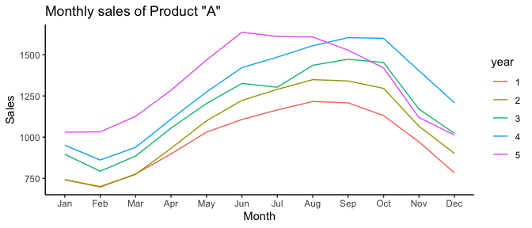

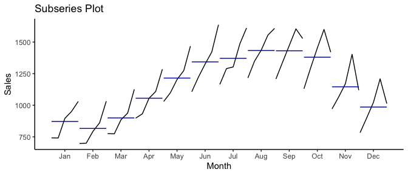

The plots show that the data has a seasonal trend. Also, it seams that the seasonal trend is positively increasing with time from Feb. to reach its peak from Jun to Oct.

**b. Use a classical multiplicative decomposition to calculate the trend-cycle and seasonal indices.**

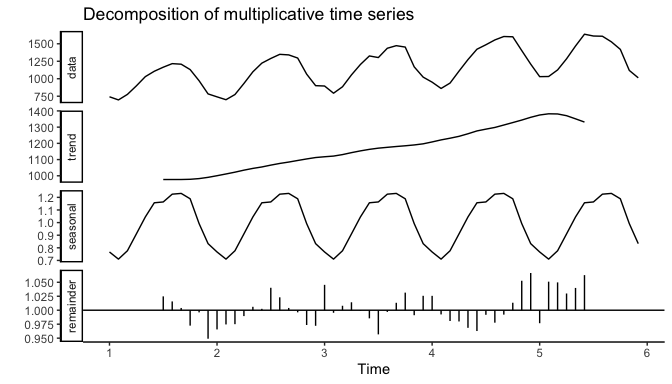

**c. Do the results support the graphical interpretation from part a?**

Yes, the plots confirms that the data is highly seasonal increasing trends.

**d. Compute and plot the seasonally adjusted data.**

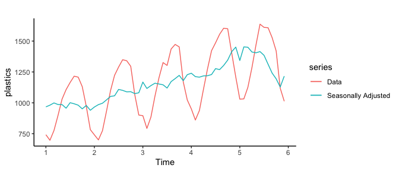

**e. Change one observation to be an motlier (e.g., add 500 to one observation), and recompute the seasonally adjusted data. What is the effect of the outlier?**

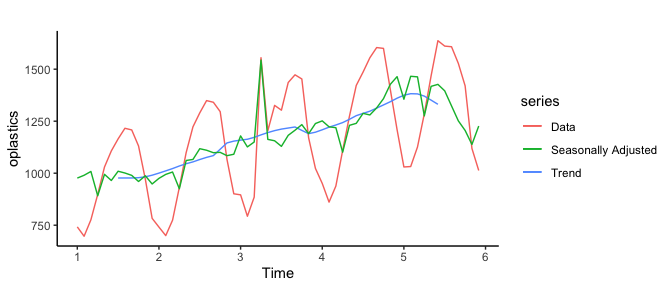

The effect of the outlier is a slight distortion in the trend’s straight line, but it has been mostly absorbed into the remainder component, as evident from the graph above. Therefore it is likely that the seasonal component hasn’t changed much because of the outlier. This conclusion is confirmed by the decomposition plot below as well.

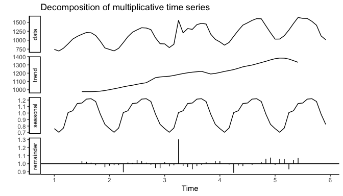

**f. Does it make any difference if the outlier is near the end rather than in the middle of the time series?**

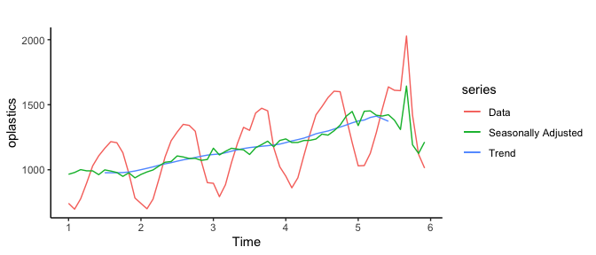

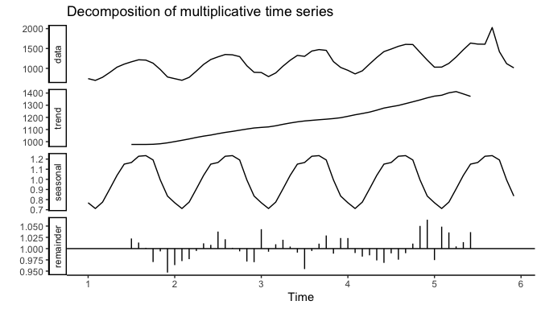

## Problem_6.3

Recall your retail time series data (from Exercise 3 in Section 2.10). Decompose the series using X11. Does it reveal any outliers, or unusual features that you had not noticed previously?

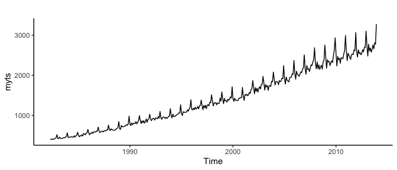

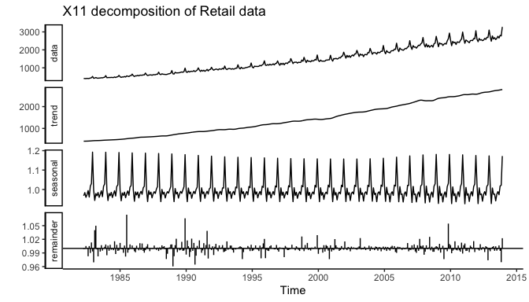

[^1] [Github repo](https://github.com/salma71/MSDS_spring2021/tree/master/data_624) | [portfolio](https://salma71.github.io/) | [Blog](https://salmaeng71.medium.com/)

[^1]: GithHub repo